# chapter5

kiirasar

2022-11-30

```r
date()
```

```
## [1] "Tue Dec 13 06:20:54 2022"
```

# Assignment 5: Tasks and Instructions

## 1. Data wrangling **(max 5 points)**

See **create_human.R** and **human_final.csv** at [data folder](https://github.com/kiirasar/IODS-project/tree/master/data).

## 2. Analysis **(max 15 points)**

First we install/use R packages we need to complete the assignment.

```r
#install.packages('ggplot2')
library(ggplot2)
library(vtable)
library(MASS)
library(tidyr)
library(dplyr)
library(corrplot)
library(GGally)
library(plotly)
library(tidyr)
```

### 1. Graphical overview and summaries of the data. Describe and interpret the distributions and the relationships. **(0-3 points)**

```r
human_ch5<- read.table("https://raw.githubusercontent.com/KimmoVehkalahti/Helsinki-Open-Data-Science/master/datasets/human2.txt", sep=",", header=T)
View(human_ch5) #human chapter 5
```

```r
st(human_ch5)
```

Summary Statistics

| Variable | N | Mean | Std. Dev. | Min | Pctl. 25 | Pctl. 75 | Max |
| --- | --- | --- | --- | --- | --- | --- | --- |
| Edu2.FM | 155 | 0.853 | 0.242 | 0.172 | 0.726 | 0.997 | 1.497 |
| Labo.FM | 155 | 0.707 | 0.199 | 0.186 | 0.598 | 0.854 | 1.038 |
| Edu.Exp | 155 | 13.176 | 2.84 | 5.4 | 11.25 | 15.2 | 20.2 |
| Life.Exp | 155 | 71.654 | 8.332 | 49 | 66.3 | 77.25 | 83.5 |
| GNI | 155 | 17627.903 | 18543.852 | 581 | 4197.5 | 24512 | 123124 |
| Mat.Mor | 155 | 149.084 | 211.79 | 1 | 11.5 | 190 | 1100 |
| Ado.Birth | 155 | 47.159 | 41.112 | 0.6 | 12.65 | 71.95 | 204.8 |
| Parli.F | 155 | 20.912 | 11.488 | 0 | 12.4 | 27.95 | 57.5 |

The human2 has 155 observations (rows, participants) and data has 8 variables (columns):

- **Edu2.FM:** Ratio of female and male populations with secondary education
- **Labo.FM:** Ratio of labor force participation of females and males
- **Edu.Exp:** Expected Years of Education
- **Life.Exp:** Life Expectancy at Birth
- **GNI:** Gross National Income (GNI) per Capita
- **Mat.Mor:** Maternal Mortality Ratio
- **Ado.Birth:** Adolescent Birth Rate
- **Parli.F:** Percent Representation in Parliament (of females I assume)

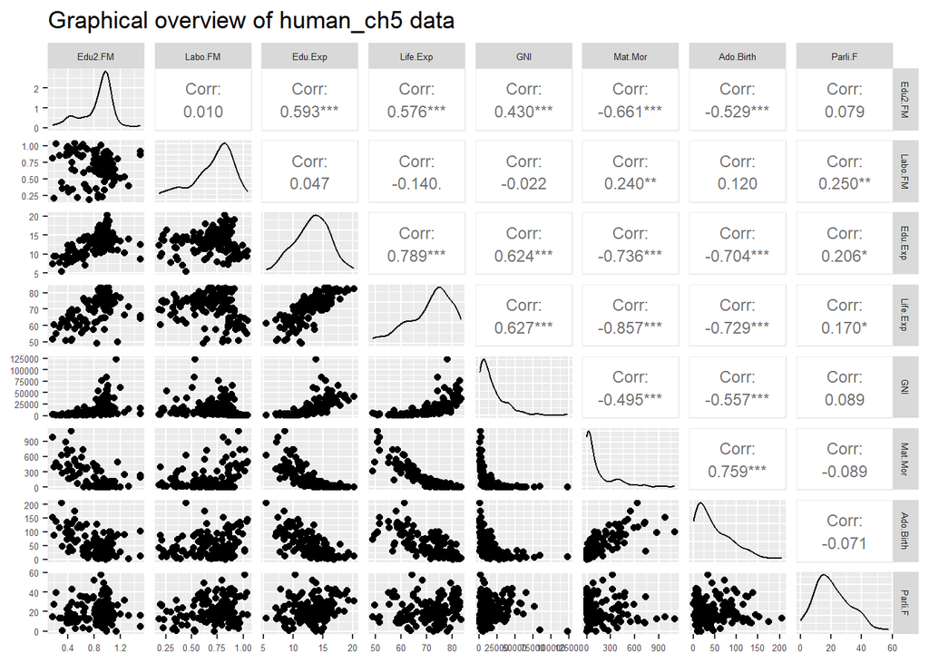

```r
gg = ggpairs(human_ch5, mapping = aes(), lower = list(combo = wrap("facethist", bins = 20)), upper = list(continuous = wrap("cor",  size=3)), title="Graphical overview of human_ch5 data")
gg1 = gg + theme(axis.text = element_text(size=5), strip.text.x = element_text(size = 5), strip.text.y = element_text(size=5))
gg1
```

**Distributions:**

- **Normally distributed**: Edu2.FM, Labo.FM, Edu.Exp, Parl.F. Labo.FM is a bit skewed on right and Parl.F a bit on left. Depending how the ratio (Labo.FM) has been defined there are either more males or females in labour force participation. Based on the common knowledge about gender difference in labour I assume there are more males. Simialrly, if the Parli.F is the ratio of females in parliment, there are less females than males in parliaments.
- **Exponential distribution**: GNI, Mat.Mor and Ado.Birth have more like exponential distributions.

**Correlations:** / Most correlations were positive and based on the scatterplots they seem to have linear relations (except some variables with exponential distributions)

- **Highest correlation:** Higest correlation (-.857) was detected between **Live.Exp** and **Mat.Mor**. This means that the countries that have high life expectancy at birth have low maternal mortality ratio, and vice versa. This makes sense, since it could indicate the health care system status in each country.
- **Edu2.FM**: seem to have moderate **positive** correlation with Edu.Exp, Life.Exp and GNI, along with moderate **negative** with Mat.Mor and Ado.Birth. No correlation between Labo.FM and Parli.F.
- **Labor.FM:** has only small **positive** correlation between Mat.Mor and Parli.F
- **Edu.Exp:** has moderate **positive** correlation with Life.Exp and GNI, and **weak** Parli.F, along with moderate **negative** correlation with Mat.Mor and Ado.Birth.
- **Life.Exp:** has strong and weak **positive** correlation between GNI and Parli.F, respectively.As well as, strong **negative** correlation between Mat.Mor and Ado.Birth
- **GNI:** moderate **negative** correlation with Mat.Mor and Ado.Birth
- **Mat.Mor:** strong **positive** correlation with Ado.Birth

Overall, Maternal mortality ratio and adolescent birth rate seem to most likely have negative associations to other variables. Meaning when mortality or adolescence birth rate is high it is associated with lower life expectancy, female ratio of 2nd education, a total of years in education (in country), and GNI for each country, and vice versa. Similarly, GNI, Edu2.FM, Edu.Exp, Life.Exp are positively associated with each other. In countries where people live longer, spend more time in school, have higher/more event female/male 2nd education ratio have often high GNI. However, ratio of labor force between female and male, as well as the female representative in parliament does not seem to have that great impact on other variables.

### 2. Principal component analysis (PCA) on the raw (non-standardized) human data. **(0-2 points)**

Show the variability captured by the principal components. Draw a **biplot** displaying the observations by the first two principal components (PC1 coordinate in x-axis, PC2 coordinate in y-axis), along with **arrows** representing the original variables.

Interpret the results of both analysis (with and without standardizing).

- Are the results different?
- Why or why not?
- Include captions (brief descriptions) in your plots where you describe the results by using not just your variable names, but the actual phenomena they relate to.
- Which number affects what?

```r
pca_human_ch5 <- prcomp(human_ch5) # perform principal component analysis, PCA (with the SVD method)
summary(human_ch5)
```

```
##     Edu2.FM          Labo.FM          Edu.Exp         Life.Exp
##  Min.   :0.1717   Min.   :0.1857   Min.   : 5.40   Min.   :49.00
##  1st Qu.:0.7264   1st Qu.:0.5984   1st Qu.:11.25   1st Qu.:66.30
##  Median :0.9375   Median :0.7535   Median :13.50   Median :74.20
##  Mean   :0.8529   Mean   :0.7074   Mean   :13.18   Mean   :71.65
##  3rd Qu.:0.9968   3rd Qu.:0.8535   3rd Qu.:15.20   3rd Qu.:77.25
##  Max.   :1.4967   Max.   :1.0380   Max.   :20.20   Max.   :83.50
##       GNI            Mat.Mor         Ado.Birth         Parli.F
##  Min.   :   581   Min.   :   1.0   Min.   :  0.60   Min.   : 0.00
##  1st Qu.:  4198   1st Qu.:  11.5   1st Qu.: 12.65   1st Qu.:12.40
##  Median : 12040   Median :  49.0   Median : 33.60   Median :19.30
##  Mean   : 17628   Mean   : 149.1   Mean   : 47.16   Mean   :20.91
##  3rd Qu.: 24512   3rd Qu.: 190.0   3rd Qu.: 71.95   3rd Qu.:27.95
##  Max.   :123124   Max.   :1100.0   Max.   :204.80   Max.   :57.50
```

This is the “raw” un-standardized data. You see that the range in values between the variables differ a lot (min-max), so it is very hard to draw any conclusions or interpreted the findings.

```r
s2 <- summary(pca_human_ch5)
pca_pr2 <- round(100*s2$importance[2, ], digits =1) # rounded percentanges of variance captured by each PC
print(pca_pr2) # print out the percentages of variance
```

```
## PC1 PC2 PC3 PC4 PC5 PC6 PC7 PC8
## 100   0   0   0   0   0   0   0
```

```r
# create object pc_lab to be used as axis labels
pc_lab2 = paste0(names(pca_pr2), " (", pca_pr2, "%)")
pc_lab2
```

```
## [1] "PC1 (100%)" "PC2 (0%)"   "PC3 (0%)"   "PC4 (0%)"   "PC5 (0%)"
## [6] "PC6 (0%)"   "PC7 (0%)"   "PC8 (0%)"
```

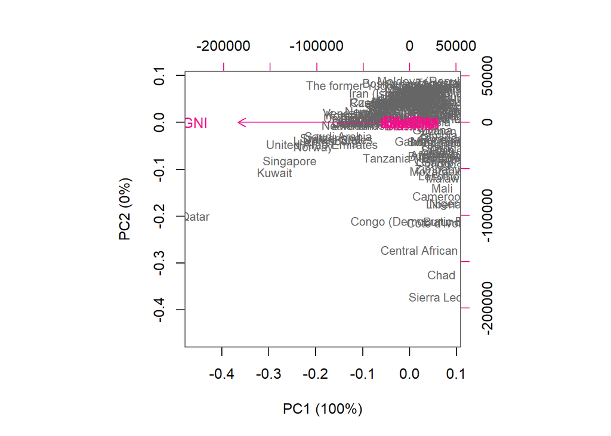

```r
biplot(pca_human_ch5, cex = c(0.8, 1), col = c("grey40", "deeppink2"), xlab = pc_lab2[1], ylab = pc_lab2[2])
```

### 3. Standardize human data and repeat the above analysis. **(0-4 points)**

```r
human_ch5_std <- scale(human_ch5) # standardize the data
summary(human_ch5_std) # summaries
```

```
##     Edu2.FM           Labo.FM           Edu.Exp           Life.Exp
##  Min.   :-2.8189   Min.   :-2.6247   Min.   :-2.7378   Min.   :-2.7188
##  1st Qu.:-0.5233   1st Qu.:-0.5484   1st Qu.:-0.6782   1st Qu.:-0.6425
##  Median : 0.3503   Median : 0.2316   Median : 0.1140   Median : 0.3056
##  Mean   : 0.0000   Mean   : 0.0000   Mean   : 0.0000   Mean   : 0.0000
##  3rd Qu.: 0.5958   3rd Qu.: 0.7350   3rd Qu.: 0.7126   3rd Qu.: 0.6717
##  Max.   : 2.6646   Max.   : 1.6632   Max.   : 2.4730   Max.   : 1.4218
##       GNI             Mat.Mor          Ado.Birth          Parli.F
##  Min.   :-0.9193   Min.   :-0.6992   Min.   :-1.1325   Min.   :-1.8203
##  1st Qu.:-0.7243   1st Qu.:-0.6496   1st Qu.:-0.8394   1st Qu.:-0.7409
##  Median :-0.3013   Median :-0.4726   Median :-0.3298   Median :-0.1403
##  Mean   : 0.0000   Mean   : 0.0000   Mean   : 0.0000   Mean   : 0.0000
##  3rd Qu.: 0.3712   3rd Qu.: 0.1932   3rd Qu.: 0.6030   3rd Qu.: 0.6127
##  Max.   : 5.6890   Max.   : 4.4899   Max.   : 3.8344   Max.   : 3.1850
```

When the data is standardized (M=0, SD=1) the comparison between the variables becomes easier. You can still see that there is huge difference between the countries (max-min) in GNI and Maternal Mortality Ratio (Mat.Mor).

```r
pca_human_ch5_std <- prcomp(human_ch5_std)
s3 <- summary(pca_human_ch5_std)
pca_pr2_std <- round(100*s3$importance[2, ], digits =1) # rounded percentanges of variance captured by each PC
print(pca_pr2_std) # print out the percentages of variance
```

```
##  PC1  PC2  PC3  PC4  PC5  PC6  PC7  PC8
## 53.6 16.2  9.6  7.6  5.5  3.6  2.6  1.3
```

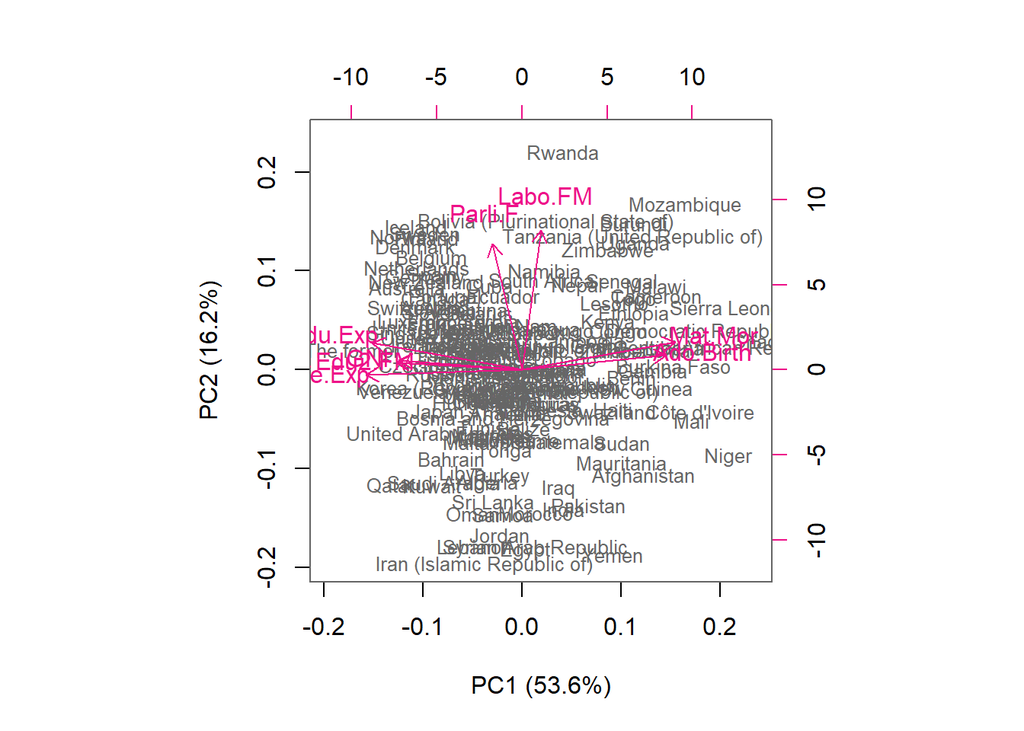

```r
pc_lab2_std = paste0(names(pca_pr2_std), " (", pca_pr2_std, "%)")

#PCA
biplot(pca_human_ch5_std, cex = c(0.8, 1), col = c("grey40", "deeppink2"), xlab = pc_lab2_std[1], ylab = pc_lab2_std[2])
```

### 4. Interpretations of the first two principal component dimensions PCA standardized human data (biplot). **(0-2 points)**

Interpret the results of both analysis (with and without standardizing).

- Include captions (brief descriptions) in your plots where you describe the results by using not just your variable names, but the actual phenomena they relate to.
- Are the results different?
- Why or why not?
- Which number affects what?

**Instructions based on the exercise:**

A biplot is a way of visualizing the connections between two representations of the same data. First, a simple scatter plot is drawn where the observations are represented by two principal components (PC’s). Then, arrows are drawn to visualize the connections between the original variables and the PC’s. The following connections hold:

- The angle between the arrows can be interpreted as the correlation between the variables.
- The angle between a variable and a PC axis can be interpreted as the correlation between the two.
- The length of the arrows are proportional to the standard deviations of the variables.

**Other resources:**

I also found another link [BioTuring](https://blog.bioturing.com/2018/06/18/how-to-read-pca-biplots-and-scree-plots/) which I found quite useful:

- Bottom axis: PC1 score
- Left axis: PC2 score
- Top axis: loadings on PC1
- Right axis: loadings on PC2
- vectors that are close to each other are positively correlated
- 90 degree = no correlation
- 180 degree = negative correlation.

**Biplot (unstandardized)**

Biplot is used to visualize associations between variables. The **country names** are located based on the two principal components (PC1 and PC2), the **arrows** indicate how the different variables (e.g., GNI, Life expectancy etc., are related to the components).

Since, the data is unstandardized the values (min-max) of the variables determine the connection. The **length of the arrow** indicates the standard deviations of the variable. Since, **GNI** had a range between 581 (Central African Republic) and 123124 (Qatar), which is far bigger than any other variable (hence biggest standard deviations), it overpowers the biplot. Country with highest GNI is **Qatar**, followed by Kuwait, and Singapore are closest to GNI (x-axis). Countries with lowest GNIs (Central African Republic, Congo, Malawi etc.,) are located furthest from GNI (x-axis). We need to use standardized data, so we can draw better conclusions of how these variables are associated to this phenomena.

When the data is standardized you can compare the variables better and those are spread around the biplot, unlike in unstandardized version where GNI was the only one, due to its large values and range between the countries.

In other words, countries that have high education (in years, and female ratio), life expectancy and GNI, often have low maternal mortality and adolescents pregnancy rates. Countries with high Education-components and low Birth-components are presented left side. For example, Iceland and Norway (top left), Korea and Japan (mid-left), and Qatar and Iran (bottom-left). And vice versa on (right side).

However, based on the arrow lengths there is high variability between the countries for each variable (longer the arrow, higher standard deviation).

To summarize, countries with high Education, low Birth and high Labor components are located left top corner.

### 5. Tea data **(0-4 points)**

Tea data comes from the **FactoMineR** package and it is measured with a questionnaire on tea: 300 individuals were asked how they drink tea (18 questions) and what are their product’s perception (12 questions). In addition, some personal details were asked (4 questions).

Load the tea dataset and convert its character variables to factors:

```r
tea <- read.csv("https://raw.githubusercontent.com/KimmoVehkalahti/Helsinki-Open-Data-Science/master/datasets/tea.csv", stringsAsFactors = TRUE)
```

**Explore the data briefly:**

- look at the structure and
- the dimensions of the data.
- Use View(tea) to browse its contents, and
- visualize the data.

```r
View(tea)
dim(tea) #300 observations, 36 variables
```

```
## [1] 300  36
```

```r
str(tea)
```

```
## 'data.frame':    300 obs. of  36 variables:
##  $ breakfast       : Factor w/ 2 levels "breakfast","Not.breakfast": 1 1 2 2 1 2 1 2 1 1 ...
##  $ tea.time        : Factor w/ 2 levels "Not.tea time",..: 1 1 2 1 1 1 2 2 2 1 ...
##  $ evening         : Factor w/ 2 levels "evening","Not.evening": 2 2 1 2 1 2 2 1 2 1 ...
##  $ lunch           : Factor w/ 2 levels "lunch","Not.lunch": 2 2 2 2 2 2 2 2 2 2 ...
##  $ dinner          : Factor w/ 2 levels "dinner","Not.dinner": 2 2 1 1 2 1 2 2 2 2 ...
##  $ always          : Factor w/ 2 levels "always","Not.always": 2 2 2 2 1 2 2 2 2 2 ...
##  $ home            : Factor w/ 2 levels "home","Not.home": 1 1 1 1 1 1 1 1 1 1 ...
##  $ work            : Factor w/ 2 levels "Not.work","work": 1 1 2 1 1 1 1 1 1 1 ...
##  $ tearoom         : Factor w/ 2 levels "Not.tearoom",..: 1 1 1 1 1 1 1 1 1 2 ...
##  $ friends         : Factor w/ 2 levels "friends","Not.friends": 2 2 1 2 2 2 1 2 2 2 ...
##  $ resto           : Factor w/ 2 levels "Not.resto","resto": 1 1 2 1 1 1 1 1 1 1 ...
##  $ pub             : Factor w/ 2 levels "Not.pub","pub": 1 1 1 1 1 1 1 1 1 1 ...
##  $ Tea             : Factor w/ 3 levels "black","Earl Grey",..: 1 1 2 2 2 2 2 1 2 1 ...
##  $ How             : Factor w/ 4 levels "alone","lemon",..: 1 3 1 1 1 1 1 3 3 1 ...
```

[output cut: 22 more lines]

Tea data has 300 observations, 36 variables. Most seem to be factors with two levels (“dummy variables”), but there are some with 3, 4 and even 5-7 values. Age is the only numeric (integral) value.

```r
library(dplyr)
library(tidyr)
# column names to keep in the dataset
tea_when <- c("breakfast", "tea.time", "evening", "lunch", "dinner", "always", "frequency")
tea_where = c("where", "home", "work", "tearoom", "friends", "resto", "pub")
tea_how = c("sugar", "Tea", "How", "how", "price")
tea_who = c("age_Q", "sex", "SPC", "Sport")
tea_why = c("escape.exoticism", "spirituality", "healthy", "diuretic", "friendliness", "iron.absorption", "feminine", "sophisticated", "slimming", "exciting", "relaxing", "effect.on.health")
```

```r
# When
tea_when <- select(tea, tea_when)
```

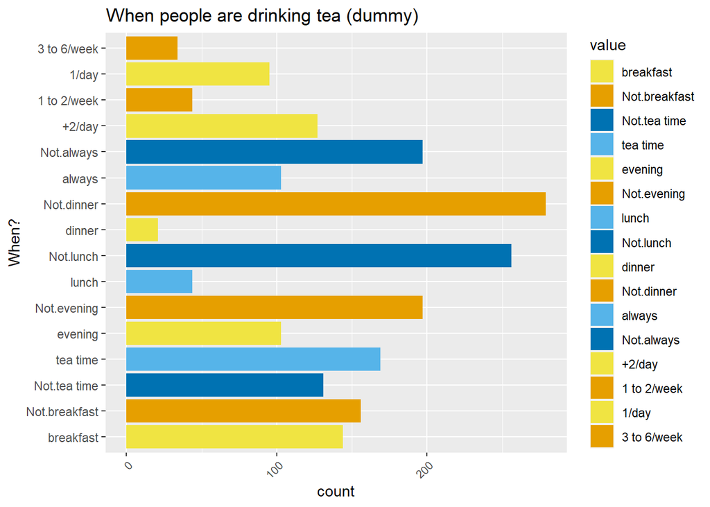

```r
cb_pal= c("#F0E442", "#E69F00",
          "#0072B2", "#56B4E9",
          "#F0E442", "#E69F00",
          "#56B4E9", "#0072B2",
          "#F0E442", "#E69F00",
          "#56B4E9", "#0072B2",
          "#F0E442", "#E69F00","#F0E442", "#E69F00")

pivot_longer(tea_when, cols = everything()) %>%
  ggplot(aes(x=value, fill=value)) +
  theme(axis.text.x = element_text(angle = 45, hjust = 1, size = 8))+
  coord_flip() +
  geom_bar() +
   scale_fill_manual(values = cb_pal) +
  labs(title = "When people are drinking tea (dummy)", x="When?")
```

People tend to drink tea:

- at least once a day (1/day or +2(day)
- around than a half were drinking during breakfast, and had specific time when to drink tea
- around one in thirst would also have tea in the evening and have alwayd drank tea.
- most people avoided tea drinking during lunch or dinner.

```r
# Where
tea_where <- select(tea, tea_where)
```

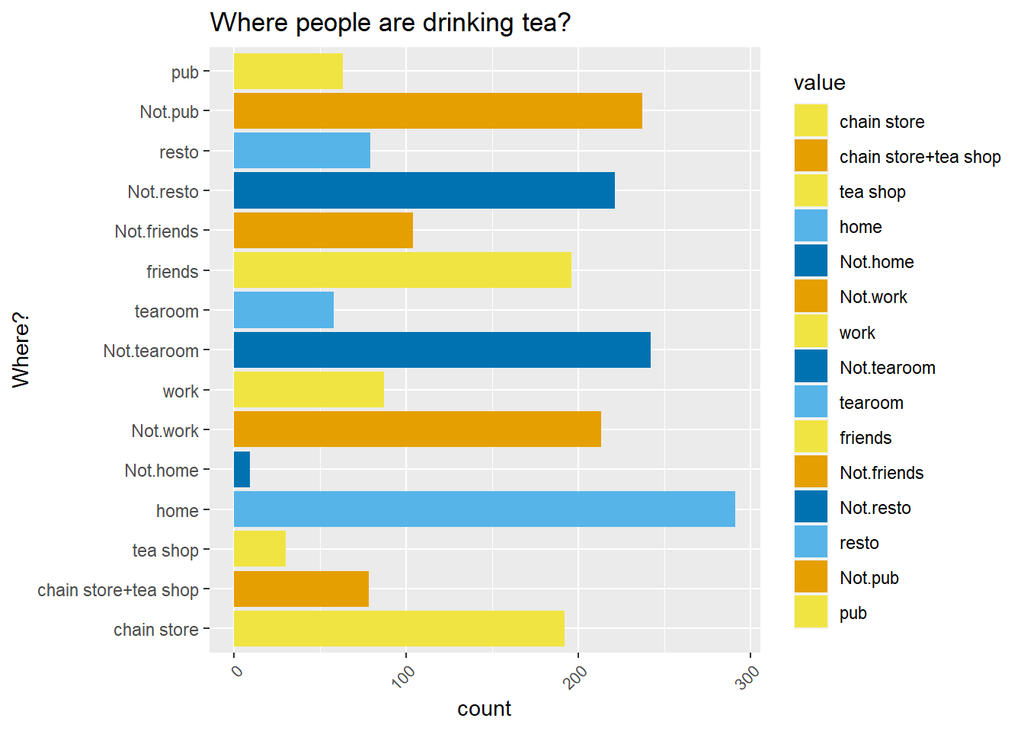

```r
cb_pal= c("#F0E442", "#E69F00","#F0E442",
          "#56B4E9", "#0072B2",
          "#E69F00", "#F0E442",
          "#0072B2", "#56B4E9",
          "#F0E442", "#E69F00",
          "#0072B2", "#56B4E9",
          "#E69F00", "#F0E442")

pivot_longer(tea_where, cols = everything()) %>%
  ggplot(aes(x=value, fill=value)) +
  theme(axis.text.x = element_text(angle = 45, hjust = 1, size = 8))+
  coord_flip() +
  geom_bar() +
   scale_fill_manual(values = cb_pal) +
  labs(title = "Where people are drinking tea?", x="Where?")
```

- The most common places to drink tea were was at home
- people often purchase their tea at chain store instead of from a specific tea store
- approximately 25% drank tea a work
- people rarely drank tea at tearooms, restaurants or pubs
- most people were drinking tea with friends

```r
# How
tea_how <- select(tea, tea_how)
```

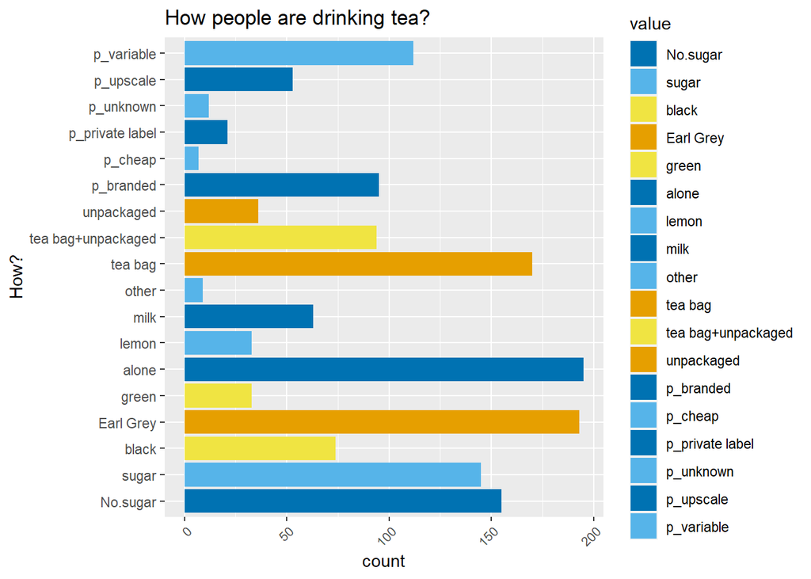

```r
cb_pal= c("#0072B2", "#56B4E9",
          "#F0E442", "#E69F00", "#F0E442",
          "#0072B2", "#56B4E9", "#0072B2", "#56B4E9",
          "#E69F00", "#F0E442", "#E69F00",
          "#0072B2", "#56B4E9", "#0072B2", "#56B4E9","#0072B2", "#56B4E9")

pivot_longer(tea_how, cols = everything()) %>%
  ggplot(aes(x=value, fill=value)) +
  theme(axis.text.x = element_text(angle = 45, hjust = 1, size = 8))+
  coord_flip() +
  geom_bar() +
   scale_fill_manual(values = cb_pal) +
  labs(title = "How people are drinking tea?", x="How?")
```

- approximately half had tea with sugar, other half without
- most people were drinking early grey, then black and last green tea
- most people did not add any addings to their tea, some had milk (approx 60 people), lemon (approx 25 people) or other (approx 10 people) addings.
- most used tea bags, almost 100 people used teabagd and unpacked tea, and less than 50 people used only unpacked tea products.
- most people bought different types of tea, or used certain specific brands. People rarely bought cheap tea, or variaety they did not know. over 50 people bought upscaled tea (whatever that means)

```r
# Who
tea_who <- select(tea, tea_who)
```

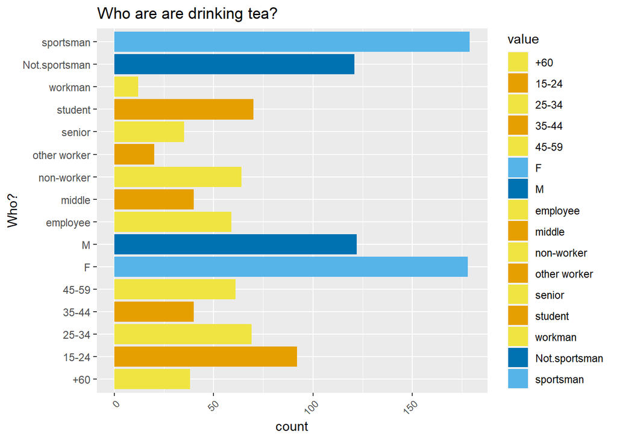

```r
cb_pal= c("#F0E442", "#E69F00","#F0E442", "#E69F00","#F0E442",
          "#56B4E9", "#0072B2",
          "#F0E442", "#E69F00", "#F0E442", "#E69F00","#F0E442", "#E69F00", "#F0E442",
          "#0072B2", "#56B4E9")

pivot_longer(tea_who, cols = everything()) %>%
  ggplot(aes(x=value, fill=value)) +
  theme(axis.text.x = element_text(angle = 45, hjust = 1, size = 8))+
  coord_flip() +
  geom_bar() +
   scale_fill_manual(values = cb_pal) +
  labs(title = "Who are are drinking tea?", x="Who?")
```

most common people who drank tea (or at least answered this survey) were:

- females
- 15-24 or 25-34 years old
- students, non-workers or employees
- considered themselves “sportman”

```r
# Why
tea_why <- select(tea, tea_why)
```

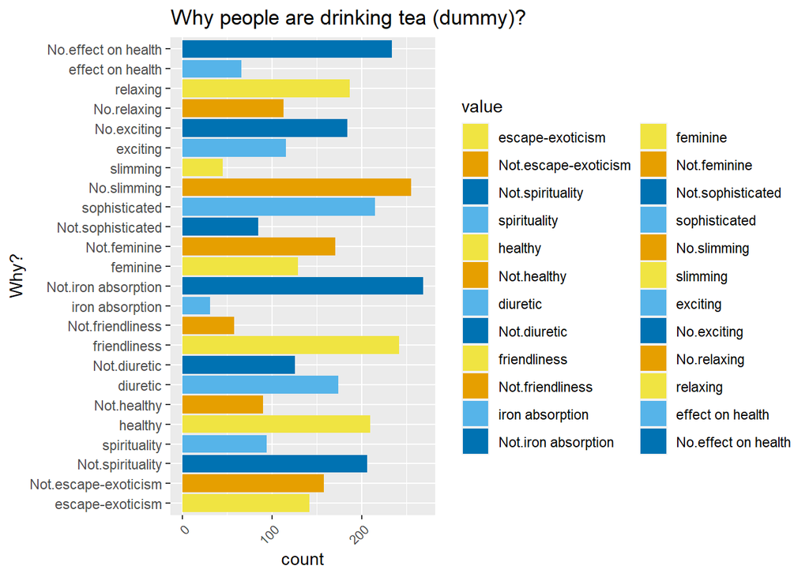

```r
cb_pal= c("#F0E442", "#E69F00",
          "#0072B2", "#56B4E9",
          "#F0E442", "#E69F00",
          "#56B4E9", "#0072B2",
          "#F0E442", "#E69F00",
          "#56B4E9", "#0072B2",
          "#F0E442", "#E69F00",
          "#0072B2", "#56B4E9",
          "#E69F00", "#F0E442",
          "#56B4E9", "#0072B2",
          "#E69F00", "#F0E442",
          "#56B4E9", "#0072B2")

pivot_longer(tea_why, cols = everything()) %>%
  ggplot(aes(x=value, fill=value)) +
  theme(axis.text.x = element_text(angle = 45, hjust = 1, size = 8))+
  coord_flip() +
  geom_bar() +
   scale_fill_manual(values = cb_pal) +
  labs(title = "Why people are drinking tea (dummy)?", x="Why?")
```

people drank tea because:

- Majority of people drank tea because they wanted to relax, tea is a diuretic and healthy product, or social reasons and because they think it is sophisticated manner.
- rarely people drank due to its health effects, excitement, slimming purposes, absorption iron, or spiritual reasons
- 50-50 though drinking tea was feminine or they wanted to escape exoticism (what ever that means).

### Instructions

- Use Multiple Correspondence Analysis (MCA) on the tea data (or on just certain columns of the data, it is up to you!).
- Interpret the results of the MCA and
- draw at least the variable **biplot** of the analysis.
- You can also explore other plotting options for MCA.
- Comment on the output of the plots.
- Look at the summary of the model.
- Plot the variables of the model. You can either plot the variables or the individuals or both. You can change which one to plot with the `invisible` argument.

```r
#install.packages("FactoMineR")
library(FactoMineR)

#mca_tea <- MCA(tea, graph = FALSE) # multiple correspondence analysis
mca_when <- MCA(tea_when, graph = FALSE) # multiple correspondence analysis
mca_where <- MCA(tea_where, graph = FALSE)
mca_how <- MCA(tea_how, graph = FALSE)
mca_who <- MCA(tea_who, graph = FALSE)
mca_why <- MCA(tea_why, graph = FALSE)

# summary of the model
summary(mca_when)
```

```
##
## Call:
## MCA(X = tea_when, graph = FALSE)
##
##
## Eigenvalues
##                        Dim.1   Dim.2   Dim.3   Dim.4   Dim.5   Dim.6   Dim.7
## Variance               0.241   0.208   0.167   0.144   0.135   0.117   0.108
## % of var.             18.738  16.185  13.015  11.216  10.516   9.118   8.407
## Cumulative % of var.  18.738  34.922  47.937  59.153  69.669  78.787  87.194
##                        Dim.8   Dim.9
## Variance               0.094   0.071
## % of var.              7.280   5.526
## Cumulative % of var.  94.474 100.000
##
## Individuals (the 10 first)
##                  Dim.1    ctr   cos2    Dim.2    ctr   cos2    Dim.3    ctr
## 1             |  0.227  0.072  0.062 | -0.707  0.801  0.601 | -0.120  0.029
## 2             |  0.227  0.072  0.062 | -0.707  0.801  0.601 | -0.120  0.029
## 3             |  0.428  0.253  0.068 |  0.255  0.104  0.024 |  0.181  0.065
## 4             |  1.218  2.052  0.550 | -0.369  0.219  0.051 | -0.049  0.005
## 5             | -0.459  0.291  0.189 |  0.267  0.114  0.064 | -0.649  0.839
## 6             |  1.218  2.052  0.550 | -0.369  0.219  0.051 | -0.049  0.005
## 7             | -0.071  0.007  0.003 | -0.247  0.098  0.039 |  0.679  0.920
## 8             |  0.296  0.121  0.060 |  0.632  0.640  0.274 |  0.272  0.147
## 9             | -0.412  0.235  0.264 | -0.439  0.308  0.298 | -0.013  0.000
## 10            | -0.317  0.139  0.110 | -0.035  0.002  0.001 | -0.182  0.066
##                 cos2
## 1              0.017 |
## 2              0.017 |
## 3              0.012 |
## 4              0.001 |
## 5              0.377 |
## 6              0.001 |
## 7              0.294 |
## 8              0.051 |
## 9              0.000 |
## 10             0.036 |
##
## Categories (the 10 first)
```

[output cut: 17 more lines]

```
## Not.evening   -0.122  0.828  0.028 -2.906 |
## lunch          1.025 13.160  0.181  7.349 |
## Not.lunch     -0.176  2.262  0.181 -7.349 |
## dinner        -0.086  0.044  0.001 -0.406 |
## Not.dinner     0.006  0.003  0.001  0.406 |
##
## Categorical variables (eta2)
##                 Dim.1 Dim.2 Dim.3
## breakfast     | 0.331 0.305 0.022 |
## tea.time      | 0.175 0.006 0.173 |
## evening       | 0.060 0.290 0.028 |
## lunch         | 0.208 0.082 0.181 |
## dinner        | 0.330 0.000 0.001 |
## always        | 0.053 0.209 0.402 |
## frequency     | 0.530 0.565 0.365 |
```

Tips how to read this summary and the plot below can be found [here](http://www.sthda.com/english/articles/31-principal-component-methods-in-r-practical-guide/114-mca-multiple-correspondence-analysis-in-r-essentials/) and [here](https://www.displayr.com/interpret-correspondence-analysis-plots-probably-isnt-way-think/)

**Explained variance**

- More variance is explained the dewer insight is missing
- The first dimension explains the variance of when people are drinking tea 19%. teh second 16% and so on. The last dimension (9) only explains 5% of the variance.
- The dimension 1 (19%) and 2 (16%) already explains 35% of the total variance. **NOTE.** Not all variables will fit this interpretation of two-dimensionality.
- All in all, when people are drinking tea is not alone good-enough to explain the differences in peoples tea habits. **cos2 cateogries**
- When the sum of **cos2** is close to one, the variables are well presented.
- For example, in this summary both breakfast can be explained by 2 dimensions (approx. cos2 in Dim2 is .300),
- but dinner is mostly explained by the first dimension (cos2 is .330, when for dim2 and dim3 is zero).
- cos2 individuals would go through how these are representing each participant who took a part in this survey.

**Eta2**

- is often used to describe the effect size, unsure if that is the case here too. simplified version of explaining eta is to try ro rhink that it is a proportion of total variance explained in specific variable when it is part of certain group. For exampe, dinner is mainly associated with dimension1.

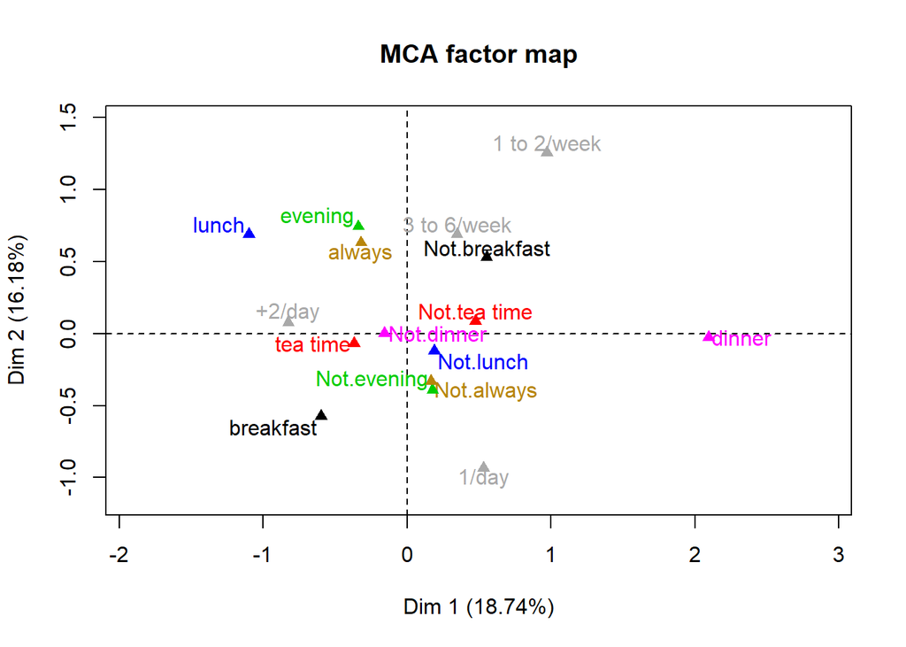

```r
# visualize MCA
plot(mca_when, invisible=c("ind"), graph.type = "classic", habillage = "quali")
```

- The variables categories with similar profiles are grouped together.
- The further the labels are from the origin he more discriminating they are
- Negatively correlated variables are opposite sides of the plot origin.
- The distance between category points and the origin measures the quality of the variable category on the factor map. Category points that are away from the origin are well represented on the factor map.

```r
summary(mca_where)
```

```
##
## Call:
## MCA(X = tea_where, graph = FALSE)
##
##
## Eigenvalues
##                        Dim.1   Dim.2   Dim.3   Dim.4   Dim.5   Dim.6   Dim.7
## Variance               0.264   0.163   0.148   0.132   0.123   0.118   0.102
## % of var.             23.080  14.269  12.931  11.550  10.777  10.323   8.949
## Cumulative % of var.  23.080  37.348  50.279  61.830  72.606  82.930  91.879
##                        Dim.8
## Variance               0.093
## % of var.              8.121
## Cumulative % of var. 100.000
##
## Individuals (the 10 first)
##                         Dim.1    ctr   cos2    Dim.2    ctr   cos2    Dim.3
## 1                    | -0.639  0.516  0.763 |  0.023  0.001  0.001 | -0.178
## 2                    | -0.639  0.516  0.763 |  0.023  0.001  0.001 | -0.178
## 3                    |  0.285  0.103  0.083 |  0.567  0.657  0.327 | -0.066
## 4                    | -0.639  0.516  0.763 |  0.023  0.001  0.001 | -0.178
## 5                    | -0.639  0.516  0.763 |  0.023  0.001  0.001 | -0.178
## 6                    | -0.639  0.516  0.763 |  0.023  0.001  0.001 | -0.178
## 7                    | -0.313  0.124  0.286 | -0.029  0.002  0.003 | -0.153
## 8                    | -0.639  0.516  0.763 |  0.023  0.001  0.001 | -0.178
## 9                    | -0.243  0.075  0.068 | -0.276  0.155  0.088 | -0.203
## 10                   |  0.222  0.062  0.035 | -0.418  0.356  0.122 |  0.021
##                         ctr   cos2
## 1                     0.072  0.059 |
## 2                     0.072  0.059 |
## 3                     0.010  0.004 |
## 4                     0.072  0.059 |
## 5                     0.072  0.059 |
## 6                     0.072  0.059 |
## 7                     0.053  0.068 |
## 8                     0.072  0.059 |
## 9                     0.093  0.048 |
## 10                    0.001  0.000 |
##
## Categories (the 10 first)
```

[output cut: 17 more lines]

```
## Not.work               0.106  -5.623 |  -0.167   1.914   0.068  -4.519 |
## work                   0.106   5.623 |   0.409   4.687   0.068   4.519 |
## Not.tearoom            0.025   2.737 |  -0.116   1.053   0.056  -4.105 |
## tearoom                0.025  -2.737 |   0.485   4.394   0.056   4.105 |
## friends                0.005  -1.214 |   0.024   0.035   0.001   0.563 |
##
## Categorical variables (eta2)
##                        Dim.1 Dim.2 Dim.3
## where                | 0.387 0.425 0.497 |
## home                 | 0.002 0.393 0.365 |
## work                 | 0.153 0.106 0.068 |
## tearoom              | 0.436 0.025 0.056 |
## friends              | 0.311 0.005 0.001 |
## resto                | 0.322 0.182 0.023 |
## pub                  | 0.236 0.006 0.024 |
```

```r
summary(mca_how)
```

```
##
## Call:
## MCA(X = tea_how, graph = FALSE)
##
##
## Eigenvalues
##                        Dim.1   Dim.2   Dim.3   Dim.4   Dim.5   Dim.6   Dim.7
## Variance               0.325   0.259   0.247   0.239   0.208   0.205   0.200
## % of var.             12.498   9.973   9.506   9.187   8.002   7.878   7.698
## Cumulative % of var.  12.498  22.470  31.976  41.163  49.166  57.044  64.742
##                        Dim.8   Dim.9  Dim.10  Dim.11  Dim.12  Dim.13
## Variance               0.190   0.175   0.165   0.147   0.130   0.109
## % of var.              7.293   6.715   6.361   5.660   5.017   4.211
## Cumulative % of var.  72.036  78.750  85.111  90.771  95.789 100.000
##
## Individuals (the 10 first)
##              Dim.1    ctr   cos2    Dim.2    ctr   cos2    Dim.3    ctr   cos2
## 1         | -0.472  0.229  0.038 |  0.804  0.831  0.110 |  0.985  1.309  0.165
## 2         |  0.101  0.010  0.005 |  0.043  0.002  0.001 |  0.886  1.059  0.385
## 3         | -0.141  0.020  0.022 | -0.466  0.279  0.243 | -0.058  0.005  0.004
## 4         | -0.446  0.204  0.216 | -0.328  0.138  0.117 | -0.160  0.034  0.028
## 5         | -0.141  0.020  0.022 | -0.466  0.279  0.243 | -0.058  0.005  0.004
## 6         | -0.341  0.119  0.036 |  0.238  0.073  0.018 | -0.193  0.050  0.012
## 7         | -0.141  0.020  0.022 | -0.466  0.279  0.243 | -0.058  0.005  0.004
## 8         |  0.101  0.010  0.005 |  0.043  0.002  0.001 |  0.886  1.059  0.385
## 9         |  0.492  0.249  0.100 | -0.034  0.001  0.000 |  0.300  0.121  0.037
## 10        |  1.115  1.275  0.546 | -0.076  0.007  0.003 |  0.247  0.083  0.027
##
## 1         |
## 2         |
## 3         |
## 4         |
## 5         |
## 6         |
## 7         |
## 8         |
## 9         |
## 10        |
##
## Categories (the 10 first)
```

[output cut: 15 more lines]

```
## Earl Grey  -0.139   1.012   0.035  -3.238 |
## green      -1.357  16.393   0.228  -8.250 |
## alone      -0.371   7.240   0.256  -8.742 |
## lemon      -0.214   0.407   0.006  -1.301 |
## milk        0.867  12.778   0.200   7.731 |
## other       2.753  18.395   0.234   8.371 |
## tea bag     0.076   0.265   0.008   1.504 |
##
## Categorical variables (eta2)
##             Dim.1 Dim.2 Dim.3
## sugar     | 0.188 0.031 0.016 |
## Tea       | 0.289 0.077 0.447 |
## How       | 0.070 0.134 0.480 |
## how       | 0.521 0.447 0.041 |
## price     | 0.556 0.608 0.253 |
```

```r
summary(mca_who)
```

```
##
## Call:
## MCA(X = tea_who, graph = FALSE)
##
##
## Eigenvalues
##                        Dim.1   Dim.2   Dim.3   Dim.4   Dim.5   Dim.6   Dim.7
## Variance               0.460   0.436   0.318   0.288   0.279   0.255   0.248
## % of var.             15.322  14.548  10.600   9.585   9.297   8.493   8.279
## Cumulative % of var.  15.322  29.871  40.471  50.056  59.353  67.846  76.126
##                        Dim.8   Dim.9  Dim.10  Dim.11  Dim.12
## Variance               0.223   0.182   0.156   0.084   0.072
## % of var.              7.432   6.059   5.209   2.791   2.384
## Cumulative % of var.  83.557  89.616  94.825  97.616 100.000
##
## Individuals (the 10 first)
##               Dim.1    ctr   cos2    Dim.2    ctr   cos2    Dim.3    ctr   cos2
## 1          |  0.021  0.000  0.000 |  0.927  0.656  0.227 | -0.218  0.050  0.013
## 2          | -0.033  0.001  0.000 |  0.488  0.182  0.081 | -0.577  0.349  0.113
## 3          | -0.015  0.000  0.000 |  0.466  0.166  0.045 | -0.773  0.627  0.124
## 4          | -0.564  0.231  0.150 | -0.553  0.233  0.144 |  0.173  0.031  0.014
## 5          | -0.147  0.016  0.008 |  0.612  0.286  0.148 |  0.013  0.000  0.000
## 6          | -0.939  0.640  0.459 | -0.455  0.158  0.108 |  0.523  0.287  0.143
## 7          |  0.062  0.003  0.001 |  1.072  0.878  0.284 |  0.125  0.016  0.004
## 8          |  0.019  0.000  0.000 |  0.553  0.234  0.085 | -0.797  0.667  0.177
## 9          |  0.062  0.003  0.001 |  1.072  0.878  0.284 |  0.125  0.016  0.004
## 10         |  0.438  0.139  0.045 |  0.975  0.726  0.224 | -0.226  0.053  0.012
##
## 1          |
## 2          |
## 3          |
## 4          |
## 5          |
## 6          |
## 7          |
## 8          |
## 9          |
## 10         |
##
## Categories (the 10 first)
```

[output cut: 14 more lines]

```
## 25-34      |   0.755  10.318   0.170   7.139 |
## 35-44      |  -1.134  13.470   0.198  -7.688 |
## 45-59      |  -0.637   6.489   0.104  -5.566 |
## F          |  -0.531  13.167   0.412 -11.097 |
## M          |   0.775  19.210   0.412  11.097 |
## employee   |  -0.428   2.829   0.045  -3.659 |
## middle     |  -0.453   2.151   0.032  -3.072 |
## non-worker |   0.462   3.581   0.058   4.161 |
##
## Categorical variables (eta2)
##              Dim.1 Dim.2 Dim.3
## age_Q      | 0.796 0.711 0.482 |
## sex        | 0.000 0.235 0.412 |
## SPC        | 0.793 0.784 0.227 |
## Sport      | 0.249 0.016 0.151 |
```

```r
summary(mca_why)
```

```
##
## Call:
## MCA(X = tea_why, graph = FALSE)
##
##
## Eigenvalues
##                        Dim.1   Dim.2   Dim.3   Dim.4   Dim.5   Dim.6   Dim.7
## Variance               0.141   0.121   0.104   0.098   0.096   0.081   0.073
## % of var.             14.140  12.066  10.407   9.788   9.606   8.136   7.271
## Cumulative % of var.  14.140  26.207  36.613  46.401  56.007  64.143  71.414
##                        Dim.8   Dim.9  Dim.10  Dim.11  Dim.12
## Variance               0.066   0.063   0.059   0.052   0.045
## % of var.              6.626   6.280   5.905   5.237   4.537
## Cumulative % of var.  78.040  84.321  90.226  95.463 100.000
##
## Individuals (the 10 first)
##                         Dim.1    ctr   cos2    Dim.2    ctr   cos2    Dim.3
## 1                    | -0.691  1.124  0.425 | -0.345  0.329  0.106 | -0.384
## 2                    | -0.307  0.222  0.081 |  0.155  0.066  0.020 | -0.565
## 3                    | -0.215  0.109  0.071 | -0.518  0.742  0.411 | -0.255
## 4                    | -0.123  0.036  0.015 | -0.284  0.223  0.079 |  0.539
## 5                    | -0.190  0.085  0.037 | -0.038  0.004  0.001 |  0.321
## 6                    | -0.608  0.872  0.357 | -0.578  0.922  0.322 | -0.036
## 7                    | -0.608  0.872  0.357 | -0.578  0.922  0.322 | -0.036
## 8                    |  0.048  0.005  0.004 | -0.448  0.554  0.347 |  0.161
## 9                    | -0.612  0.883  0.368 | -0.205  0.116  0.041 |  0.308
## 10                   | -0.215  0.109  0.071 | -0.518  0.742  0.411 | -0.255
##                         ctr   cos2
## 1                     0.473  0.131 |
## 2                     1.023  0.274 |
## 3                     0.209  0.100 |
## 4                     0.931  0.285 |
## 5                     0.329  0.105 |
## 6                     0.004  0.001 |
## 7                     0.004  0.001 |
## 8                     0.083  0.045 |
## 9                     0.303  0.093 |
## 10                    0.209  0.100 |
##
## Categories (the 10 first)
```

[output cut: 20 more lines]

```
## friendliness         -0.287 | -0.014  0.012  0.001 -0.485 |
## Not.friendliness      0.287 |  0.057  0.051  0.001  0.485 |
##
## Categorical variables (eta2)
##                        Dim.1 Dim.2 Dim.3
## escape.exoticism     | 0.041 0.140 0.163 |
## spirituality         | 0.122 0.002 0.122 |
## healthy              | 0.230 0.285 0.093 |
## diuretic             | 0.228 0.020 0.147 |
## friendliness         | 0.102 0.000 0.001 |
## iron.absorption      | 0.068 0.008 0.011 |
## feminine             | 0.310 0.009 0.007 |
## sophisticated        | 0.215 0.030 0.090 |
## slimming             | 0.275 0.055 0.003 |
## exciting             | 0.030 0.258 0.127 |
```

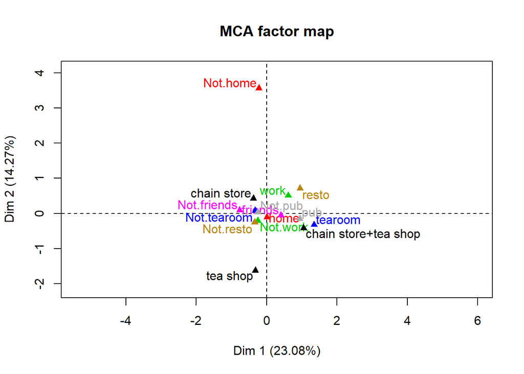

```r
# visualize MCA
plot(mca_where, invisible=c("ind"), graph.type = "classic", habillage = "quali")
```

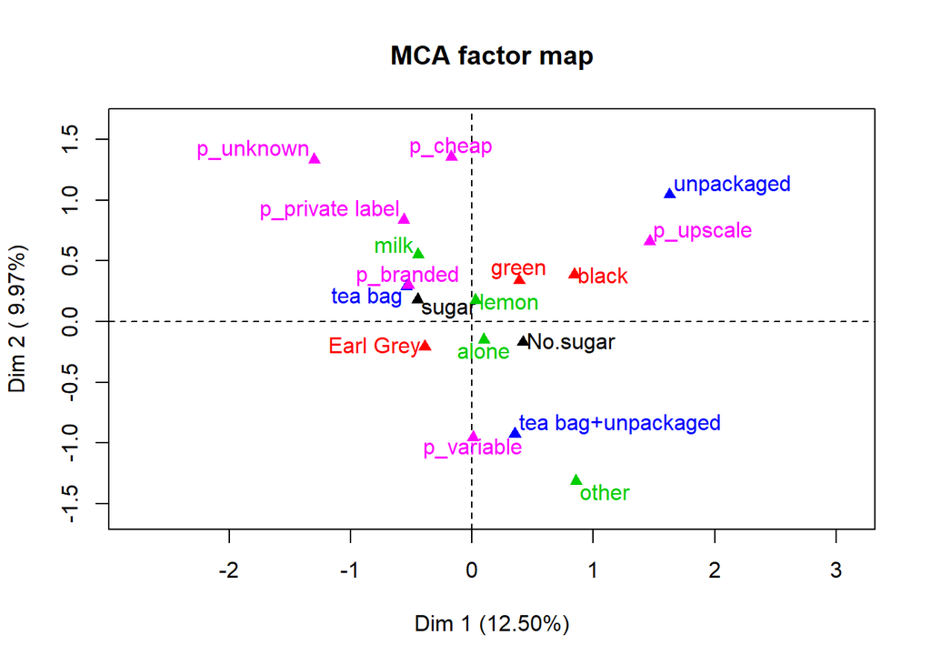

```r
plot(mca_how, invisible=c("ind"), graph.type = "classic", habillage = "quali")
```

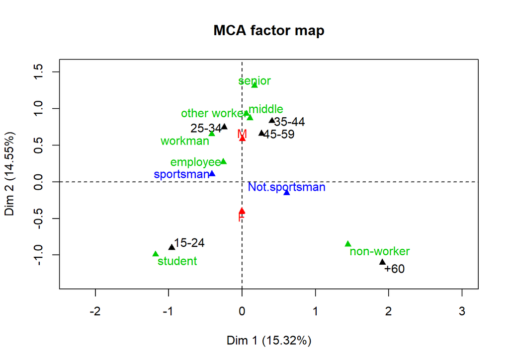

```r
plot(mca_who, invisible=c("ind"), graph.type = "classic", habillage = "quali")
```

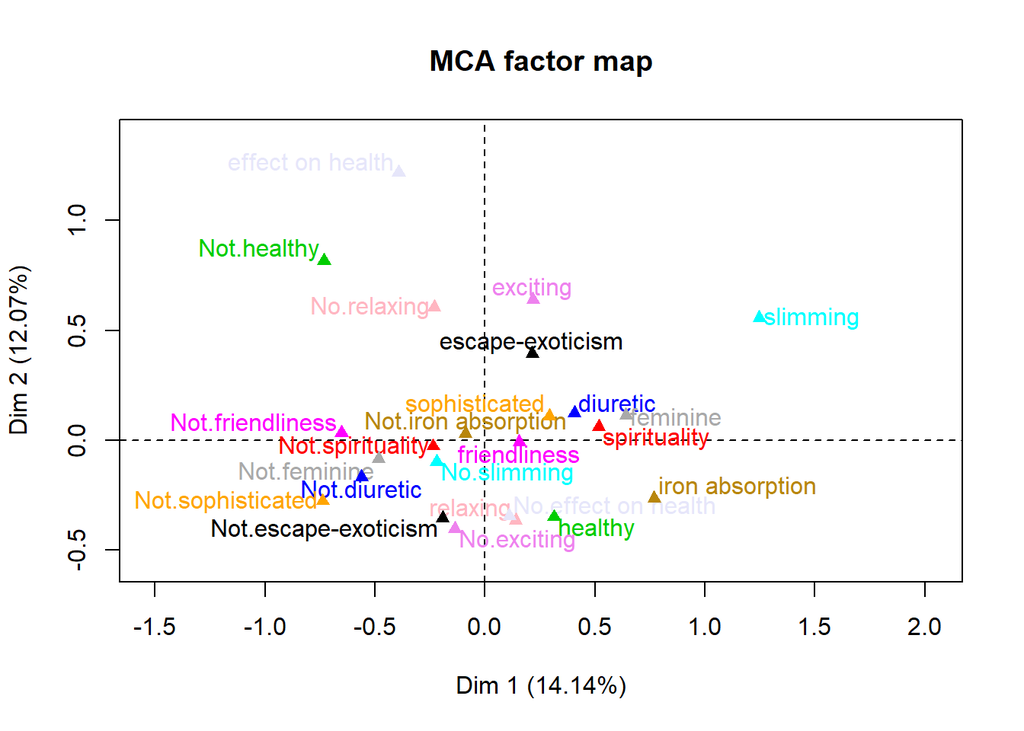

```r
plot(mca_why, invisible=c("ind"), graph.type = "classic", habillage = "quali")
```

End of Assignment 5.